# Homework 2: Matrices Solutions

## Problem 1: Matrix-Description Matching

Match the descriptions a)-f) with matrices 1)-6):

**Descriptions:**

1. Rotation by $70°$
2. Not changing anything
3. Flipping around the $x$-axis
4. Stretching out $5$ times in $y$-direction
5. Sending all vectors onto the line $y=6x$
6. Sending all vectors onto the line $y=6x+1$

**Matrices:**

1. $\begin{bmatrix} 1&0\\0&5 \end{bmatrix}$
2. Such matrix does not exist
3. $\begin{bmatrix} 1&0\\0&1 \end{bmatrix}$
4. $\begin{bmatrix} 0.342 & -0.939\\ 0.939& 0.342 \end{bmatrix}$
5. $\begin{bmatrix} 1&0\\0&-1 \end{bmatrix}$
6. $\begin{bmatrix} 3&-1\\18&-6 \end{bmatrix}$

*Hint: Compute the determinants.*

### Solutions

Let’s analyze each matrix and compute determinants:

**Matrix 1:** $\begin{bmatrix} 1&0\\0&5 \end{bmatrix}$ - $\det = 5$ ✓ (stretches $y$ by 5)

**Matrix 2:** No matrix exists for affine transformations (translations)

**Matrix 3:** $\begin{bmatrix} 1&0\\0&1 \end{bmatrix}$ - $\det = 1$ ✓ (identity matrix)

**Matrix 4:** $\begin{bmatrix} 0.342 & -0.939\\ 0.939& 0.342 \end{bmatrix}$ - $\det = 0.342^2 + 0.939^2 \approx 1$ ✓ (rotation matrix)

**Matrix 5:** $\begin{bmatrix} 1&0\\0&-1 \end{bmatrix}$ - $\det = -1$ ✓ (reflection across $x$-axis)

**Matrix 6:** $\begin{bmatrix} 3&-1\\18&-6 \end{bmatrix}$ - $\det = 3(-6) - (-1)(18) = 0$ ✓ (projects onto line)

**Matching:**

- 1. Rotation by $70°$ → **4** (Note: $\cos(70°) \approx 0.342$, $\sin(70°) \approx 0.939$)
- 2. Not changing anything → **3** (Identity matrix)
- 3. Flipping around $x$-axis → **5** (Changes $y$ to $-y$)
- 4. Stretching $5$ times in $y$-direction → **1** (Scales $y$-coordinate by 5)
- 5. Sending all vectors onto line $y=6x$ → **6** (Determinant = 0, projects onto line)
- 6. Sending all vectors onto line $y=6x+1$ → **2** (Linear transformations can’t translate)

## Problem 2: Determinants

What is the determinant of the matrix which:

1. Rotates everything by $14°$ and stretches $1.5$ times in the $x$-direction
2. Does the inverse of a)
3. Sends $[1 \quad 0]$ to $[2 \quad 4]$ and $[0 \quad 1]$ to $[-1 \quad 0]$
4. Has the form $\begin{bmatrix} 2 & 3 \\ 2 &1 \end{bmatrix}$
5. Has the form $\begin{bmatrix} 8&3&5\\1&4&2\\-4&0&4 \end{bmatrix}$
6. Is the matrix of e) raised to the power $3$

### Solutions

1. **Rotation + scaling matrix:** Rotation preserves area ($\det = 1$), scaling by $1.5$ in $x$-direction multiplies area by $1.5$. $\det = 1.5$
2. **Inverse matrix:** $\det(A^{-1}) = \frac{1}{\det(A)} = \frac{1}{1.5} = \frac{2}{3}$
3. **Matrix from column vectors:** $A = \begin{bmatrix} 2 & -1 \\ 4 & 0 \end{bmatrix}$ $\det(A) = 2(0) - (-1)(4) = 4$
4. **Direct calculation:** $\det = 2(1) - 3(2) = 2 - 6 = -4$
5. **3×3 determinant:** Using cofactor expansion along the second row: $\det = -1 \cdot \begin{vmatrix} 3&5\\0&4 \end{vmatrix} + 4 \cdot \begin{vmatrix} 8&5\\-4&4 \end{vmatrix} - 2 \cdot \begin{vmatrix} 8&3\\-4&0 \end{vmatrix}$ $= -1(12) + 4(32 + 20) - 2(0 + 12) = -12 + 208 - 24 = 172$
6. **Power property:** $\det(A^3) = (\det(A))^3 = 172^3 = 5,088,448$

## Problem 3: Missing Matrix Entries

Fill in the missing entries of $\begin{bmatrix} 2 & * \\ -1 & * \end{bmatrix}$ if it:

1. Stretches $[0 \quad 1]$ by $2$ times
2. Has trace $2$ and determinant $3$
3. Has eigenvalues $1$ and $5$

### Solutions

[📹 Video Solution in Armenian](https://youtu.be/5VEnDdm8RZo?si=19CNwGx9p8mRHDFM)

1. **Stretching $[0 \quad 1]$ by 2:** $\begin{bmatrix} 2 & * \\ -1 & * \end{bmatrix}\begin{bmatrix} 0 \\ 1 \end{bmatrix} = 2\begin{bmatrix} 0 \\ 1 \end{bmatrix} = \begin{bmatrix} 0 \\ 2 \end{bmatrix}$

   This gives us: $\begin{bmatrix} * \\ * \end{bmatrix} = \begin{bmatrix} 0 \\ 2 \end{bmatrix}$

   Therefore: $\begin{bmatrix} 2 & -3 \\ -1 & 4 \end{bmatrix}$

## Problem 4: Subspace Dimensions

A subspace of which dimension (at most) can you construct with the vectors:

1. $\mathbf{v}_1=\begin{bmatrix}6\\1\\5\end{bmatrix}, \mathbf{v}_2=\begin{bmatrix} 2\\3\\2 \end{bmatrix}$
2. $\mathbf{v}_1=\begin{bmatrix}6\\2\end{bmatrix}, \mathbf{v}_2=\begin{bmatrix} 1\\3 \end{bmatrix}, \mathbf{v}_3=\begin{bmatrix} 5\\2 \end{bmatrix}$
3. $\mathbf{v}_1=\begin{bmatrix}4\\1\\2\end{bmatrix}, \mathbf{v}_2=\begin{bmatrix} -4\\2\\-1 \end{bmatrix}, \mathbf{v}_3=\begin{bmatrix} 8\\-1\\7 \end{bmatrix}$
4. $\mathbf{v}_1=\begin{bmatrix}3\\-2\\1\end{bmatrix}, \mathbf{v}_2=\begin{bmatrix} 6\\-4\\4 \end{bmatrix}$

### Solutions

The dimension equals the number of linearly independent vectors (rank of the matrix).

1. **Two vectors in $\mathbb{R}^3$:** Check if linearly independent: $\mathbf{v}_1$ and $\mathbf{v}_2$ are not scalar multiples. **Dimension: 2** (span a plane in $\mathbb{R}^3$)
2. **Three vectors in $\mathbb{R}^2$:** At most 2 vectors can be linearly independent in $\mathbb{R}^2$. Check: $\det\begin{bmatrix} 6&1\\2&3 \end{bmatrix} = 18-2 = 16 \neq 0$ **Dimension: 2** (any two non-collinear vectors span $\mathbb{R}^2$)
3. **Three vectors in $\mathbb{R}^3$:** Form matrix: $\begin{bmatrix} 4&-4&8\\1&2&-1\\2&-1&7 \end{bmatrix}$

   Computing determinant: $\det = 4(14-1) - (-4)(7+2) + 8(-1-4) = 4(13) + 4(9) + 8(-5) = 52 + 36 - 40 = 48 \neq 0$ **Dimension: 3** (linearly independent)
4. **Two vectors in $\mathbb{R}^3$:** Check if $\mathbf{v}_2 = k\mathbf{v}_1$: $\frac{6}{3} = 2$, $\frac{-4}{-2} = 2$, but $\frac{4}{1} = 4 \neq 2$ **Dimension: 2** (linearly independent, span a plane)

## Problem 5: Eigenvalues and Eigenvectors

Find the eigenvalues and eigenvectors of the following matrices:

1. $A=\begin{bmatrix} 1&2\\0&1\end{bmatrix}$
2. $B=\begin{bmatrix} 2&1\\1&2 \end{bmatrix}$
3. $C=\begin{bmatrix} 8 & 1 \\ 8 & 1 \end{bmatrix}$
4. $D=\begin{bmatrix} -1&0&0\\0&1&0\\0&0&3 \end{bmatrix}$

You may use any technique but try to think visually.

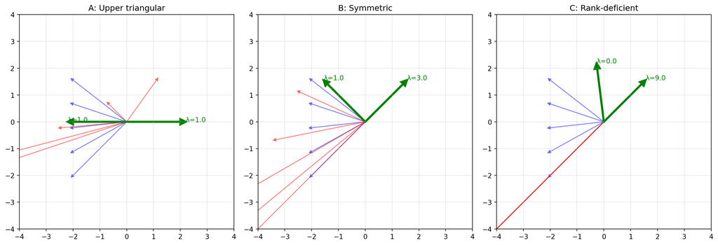

(a) Eigenvalue and Eigenvector Visualization

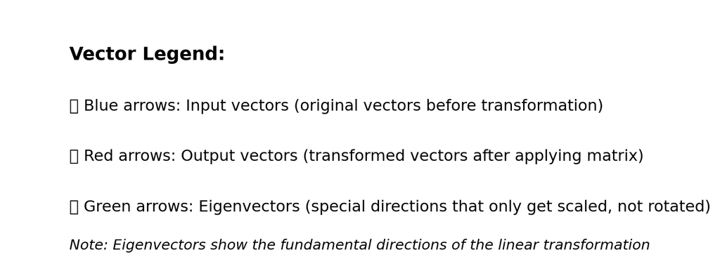

(b)

Figure 1

### Solutions

1. **Matrix $A=\begin{bmatrix} 1&2\\0&1\end{bmatrix}$ (Upper triangular):**

   Characteristic polynomial: $\det(A-\lambda I) = (1-\lambda)^2 = 0$ **Eigenvalue:** $\lambda = 1$ (repeated)

   For $\lambda = 1$: $(A-I)\mathbf{v} = \mathbf{0}$ $\begin{bmatrix} 0&2\\0&0 \end{bmatrix}\mathbf{v} = \mathbf{0}$ **Eigenvector:** $\mathbf{v} = \begin{bmatrix} 1\\0 \end{bmatrix}$ (geometric multiplicity = 1)
2. **Matrix $B=\begin{bmatrix} 2&1\\1&2 \end{bmatrix}$ (Symmetric):**

   Characteristic polynomial: $\det(B-\lambda I) = (2-\lambda)^2 - 1 = \lambda^2 - 4\lambda + 3 = (\lambda-1)(\lambda-3)$ **Eigenvalues:** $\lambda_1 = 1$, $\lambda_2 = 3$

   For $\lambda_1 = 1$: $\begin{bmatrix} 1&1\\1&1 \end{bmatrix}\mathbf{v} = \mathbf{0}$ → $\mathbf{v}_1 = \begin{bmatrix} 1\\-1 \end{bmatrix}$ For $\lambda_2 = 3$: $\begin{bmatrix} -1&1\\1&-1 \end{bmatrix}\mathbf{v} = \mathbf{0}$ → $\mathbf{v}_2 = \begin{bmatrix} 1\\1 \end{bmatrix}$
3. **Matrix $C=\begin{bmatrix} 8 & 1 \\ 8 & 1 \end{bmatrix}$ (Rank-deficient):**

   For diagonal matrices, eigenvalues are the diagonal entries: **Eigenvalues:** $\lambda_1 = -1$, $\lambda_2 = 1$, $\lambda_3 = 3$ **Eigenvectors:** $\mathbf{v}_1 = \begin{bmatrix} 1\\0\\0 \end{bmatrix}$, $\mathbf{v}_2 = \begin{bmatrix} 0\\1\\0 \end{bmatrix}$, $\mathbf{v}_3 = \begin{bmatrix} 0\\0\\1 \end{bmatrix}$

**Visual interpretation:** Eigenvectors show directions that are only scaled (not rotated) by the matrix transformation.

## Problem 6: Ellipse Area

If you take the unit circle $x^2+y^2=1$ and stretch it out $2$ times along the $x$-axis, you will get an *ellipse*. What is its area equal to?

(Additional:) Can you generalize the result to derive a formula for the area of ellipse?

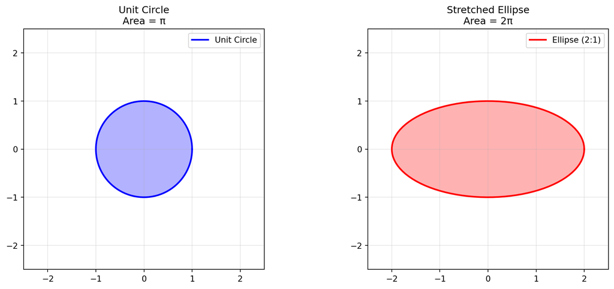

Figure 2: Unit Circle to Ellipse Transformation

### Solutions

**Main Problem:** The transformation matrix is $T = \begin{bmatrix} 2 & 0 \\ 0 & 1 \end{bmatrix}$ (stretch by 2 in $x$-direction).

The determinant is $\det(T) = 2 \cdot 1 = 2$.

Since linear transformations scale areas by the absolute value of the determinant: - Original area (unit circle): $\pi$ - New area (ellipse): $|\det(T)| \cdot \pi = 2\pi$

**Generalization:** For an ellipse with semi-axes $a$ and $b$, the transformation from unit circle is:
$$T = \begin{bmatrix} a & 0 \\ 0 & b \end{bmatrix}$$

**General ellipse area formula:** $\text{Area} = \pi ab$

**Verification:** - Unit circle: $a = b = 1 \Rightarrow \text{Area} = \pi$ - Our problem: $a = 2, b = 1 \Rightarrow \text{Area} = 2\pi$ ✓

This beautiful result shows how determinants give us area scaling factors for linear transformations!

## Problem 7: Inverse Problems

It is known that the matrix $A=\begin{bmatrix} 4 & -8 \\ 1 & 2 \end{bmatrix}$ sends a certain vector $\mathbf{v}$ to:

1. $\begin{bmatrix} 1 \\2 \end{bmatrix}$
2. $\begin{bmatrix} 3 \\ 4 \end{bmatrix}$

Can you find the vector $\mathbf{v}$?

### Solutions

We need to solve $A\mathbf{v} = \mathbf{b}$ for $\mathbf{v}$, which means $\mathbf{v} = A^{-1}\mathbf{b}$.

First, find $A^{-1}$:
$$A = \begin{bmatrix} 4 & -8 \\ 1 & 2 \end{bmatrix}$$
$$\det(A) = 4(2) - (-8)(1) = 8 + 8 = 16$$
$$A^{-1} = \frac{1}{16}\begin{bmatrix} 2 & 8 \\ -1 & 4 \end{bmatrix} = \begin{bmatrix} 1/8 & 1/2 \\ -1/16 & 1/4 \end{bmatrix}$$

1. **For $\mathbf{b} = \begin{bmatrix} 1 \\ 2 \end{bmatrix}$:**
   $$\mathbf{v} = A^{-1}\mathbf{b} = \begin{bmatrix} 1/8 & 1/2 \\ -1/16 & 1/4 \end{bmatrix}\begin{bmatrix} 1 \\ 2 \end{bmatrix} = \begin{bmatrix} 1/8 + 1 \\ -1/16 + 1/2 \end{bmatrix} = \begin{bmatrix} 9/8 \\ 7/16 \end{bmatrix}$$
2. **For $\mathbf{b} = \begin{bmatrix} 3 \\ 4 \end{bmatrix}$:**
   $$\mathbf{v} = A^{-1}\mathbf{b} = \begin{bmatrix} 1/8 & 1/2 \\ -1/16 & 1/4 \end{bmatrix}\begin{bmatrix} 3 \\ 4 \end{bmatrix} = \begin{bmatrix} 3/8 + 2 \\ -3/16 + 1 \end{bmatrix} = \begin{bmatrix} 19/8 \\ 13/16 \end{bmatrix}$$

**Verification for a):** $A\mathbf{v} = \begin{bmatrix} 4 & -8 \\ 1 & 2 \end{bmatrix}\begin{bmatrix} 9/8 \\ 7/16 \end{bmatrix} = \begin{bmatrix} 9/2 - 7/2 \\ 9/8 + 7/8 \end{bmatrix} = \begin{bmatrix} 1 \\ 2 \end{bmatrix}$ ✓

## Problem 8: Diagonal Matrix Properties (Additional)

Consider the $5 \times 5$ matrix:
$$A=\begin{bmatrix} a_1 & 0 & 0 & 0 & 0 \\ 0 & a_2 & 0 & 0 & 0 \\ 0 & 0 & a_3 & 0 & 0 \\ 0 & 0 & 0 & a_4 & 0 \\ 0 & 0 & 0 & 0 & a_5 \end{bmatrix}$$

where $a_1, \dots, a_5$ are positive numbers.

1. What is the standard basis of $\mathbb{R}^5$?
2. Where does $A$ send the standard basis vectors?
3. What is the determinant of $A$?
4. What are the eigenvalues and eigenvectors of $A$?

### Solutions

1. **Standard basis of $\mathbb{R}^5$:**
   $$\mathbf{e}_1 = \begin{bmatrix} 1\\0\\0\\0\\0 \end{bmatrix}, \mathbf{e}_2 = \begin{bmatrix} 0\\1\\0\\0\\0 \end{bmatrix}, \mathbf{e}_3 = \begin{bmatrix} 0\\0\\1\\0\\0 \end{bmatrix}, \mathbf{e}_4 = \begin{bmatrix} 0\\0\\0\\1\\0 \end{bmatrix}, \mathbf{e}_5 = \begin{bmatrix} 0\\0\\0\\0\\1 \end{bmatrix}$$
2. **Where $A$ sends the basis vectors:**
   $$A\mathbf{e}_1 = a_1\mathbf{e}_1, \quad A\mathbf{e}_2 = a_2\mathbf{e}_2, \quad A\mathbf{e}_3 = a_3\mathbf{e}_3, \quad A\mathbf{e}_4 = a_4\mathbf{e}_4, \quad A\mathbf{e}_5 = a_5\mathbf{e}_5$$

   Each basis vector is scaled by its corresponding diagonal entry.
3. **Determinant:** For diagonal matrices, the determinant is the product of diagonal entries:
   $$\det(A) = a_1 \cdot a_2 \cdot a_3 \cdot a_4 \cdot a_5$$
4. **Eigenvalues and eigenvectors:** From part (b), we see that each $\mathbf{e}_i$ is an eigenvector with eigenvalue $a_i$:
   - **Eigenvalues:** $\lambda_1 = a_1, \lambda_2 = a_2, \lambda_3 = a_3, \lambda_4 = a_4, \lambda_5 = a_5$
   - **Eigenvectors:** $\mathbf{v}_1 = \mathbf{e}_1, \mathbf{v}_2 = \mathbf{e}_2, \mathbf{v}_3 = \mathbf{e}_3, \mathbf{v}_4 = \mathbf{e}_4, \mathbf{v}_5 = \mathbf{e}_5$

**Key insight:** Diagonal matrices are the simplest linear transformations—they just scale each coordinate independently!